# Part I - (Ford GoBike System Data)

## by Dina Alade

### Table of Content

- Introduction
- Preliminary Wrangling
- Univariant Exploration
- Bivariant Exploration
- Multivariant Exploration
- Conclusion

## Introduction

> I analyzed Ford GoBike dataset. I used Python libraries like pandas, seaborn, numpy and matplotlib. The Dataset collects information from over 183k data of Bike rides. It consists of different features of user data and time.

## Dataset

It consists of 183412 rows 16 columns

Duration_sec - Trip Duration Start_time - Time the trip starts End_time - Time the trip ends Start_station_id - ID number of the station the trip started from Start_station_name - Name of the station the trip started from Start_station_latitude - Latitude of station the trip started from Start_station_longitude - Longitude of station the trip started from End_station_id - ID number of the station the trip ended End_station_name - Name of the station the trip ended End_station_latitude - Latitude of station the trip ended End_station_longitude - Longitude of station the trip ended Bike_id - ID of the bikes used Member_birth_year - Year the Bike users were born Member_gender - Gender of the Bike Users Bike_share_for_all_trip - If bike trips were shared or not.

## Visualization I

Check the frequency and count of some variables to see the activity

First, i will start with weekday

#### What day of the week had the most rental in 2019?

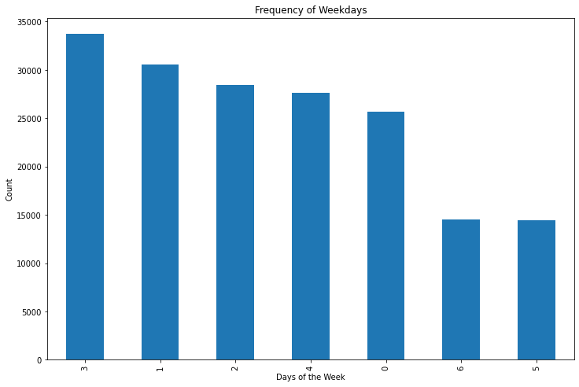

## Visualization II

#### What day in February had the highest rental rate?

Find out the day in the month of February experinced the highest amount of activity

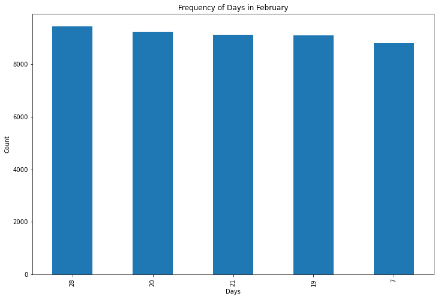

## Visualization III

### What Days of the Week Experience the longest Rides?

When in the month of February 2019 did riders ride the most?

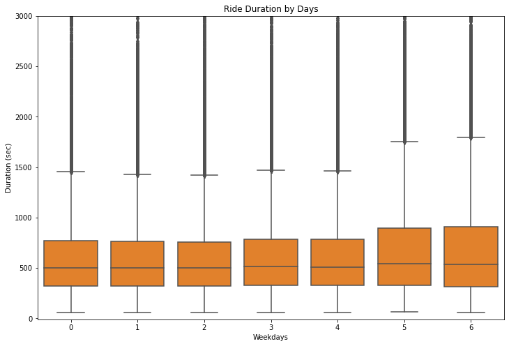

## Visualization IV

### What is the Distribution between Gender, User Type and Birth Year with time?

Let's see if a relationship can be seen between gender, user type and birth year with time(duration)

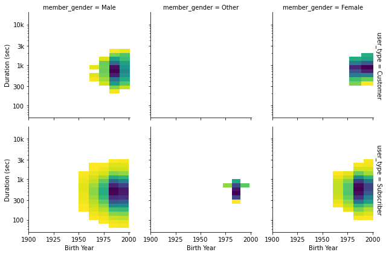